# Exploring Bay Wheels Rides Data

### by RAJAT PRASAD

Bay Wheels is a regional public bicycle sharing system in the San Francisco Bay Area, California operated by Motivate in a partnership with the Metropolitan Transportation Commission and the Bay Area Air Quality Management District. Bay Wheels is the first regional and large-scale bicycle sharing system deployed in California and on the West Coast of the United States. It was established as Bay Area Bike Share in August 2013. As of January 2018, the Bay Wheels system had over 2,600 bicycles in 262 stations across San Francisco, East Bay and San Jose. On June 28, 2017, the system officially re-launched as Ford GoBike in a partnership with Ford Motor Company. After Motivate's acquisition by Lyft, the system was subsequently renamed to Bay Wheels in June 2019.

The bicycles are available 24 hours a day, seven days a week for periods ranging from a single ride (up to 30 minutes) to a day pass, in 30-minute increments, or customers can purchase an annual subscription which gives them unlimited rides up to 45-minutes in duration. Single rides cost 2 dollar per trip, day passes cost 10 dollar per day, and memberships cost 15 dollar per month or 149 dollar per year.

For more about [Bay Wheels](https://en.wikipedia.org/wiki/Bay_Wheels).

## About Dataset

| **Variable Name** | **Variable Discription** |
| --- | --- |
| **bike_id** | Unique id of each bicycle. |
| **bike_share_for_all_trip** | A reduced pricing option for users who qualify for CalFresh, the SFMTA Lifeline pass or PG&E CARE discount. |
| **duration_sec** | Trip Duration in seconds. |
| **end_station_id** | Unique id of station at where trip ends. |
| **end_station_latitude** | Latitude of end station. |
| **end_station_longitude** | Longitude of end station. |
| **end_station_name** | Name of station where trip end. |
| **end_time** | End time of trip. |
| **rental_access_method** | How bicycle ride is access either through app or clipper. |
| **start_station_id** | Unique id of station from where trip start. |
| **start_station_latitude** | Latitude of start station. |
| **start_station_longitude** | Longitude of start station. |
| **start_station_name** | Name of station where trip start. |
| **start_time** | Start time of trip. |
| **user_type** | Whether the rider is subscriber or customer. |

For more about [Bay Wheels Dataset](https://www.lyft.com/bikes/bay-wheels/system-data).

## Importing Librarires

```python
# importing libarires
import pandas as pd
import numpy as np
import matplotlib.pyplot as plt
import seaborn as sns
import os
import pathlib
import glob
import missingno as msno

%matplotlib inline
```

## Gathering Data

```python
file_path = pathlib.Path("bay-wheels-dataset/bay_wheels_combined.csv")

if file_path.exists():
    # check if final combined dataset is avaliable, then read that dataset
    bike_df = pd.read_csv('bay-wheels-dataset/bay_wheels_combined.csv', low_memory=False)

else:
    # combining all datasets into one dataset
    os.chdir('bay-wheels-dataset')
    datasets = [dataset for dataset in glob.glob('*.{}'.format('csv'))]
    bay_wheels = pd.concat([pd.read_csv(data, low_memory=False, header=0) for data in datasets], sort=True)
    bay_wheels.to_csv("bay_wheels_combined.csv", index=False, encoding='utf-8-sig')
    os.chdir('/')
```

## Assessing Data

```python
# reading top 5 rows of dataset
bike_df.head()
```

|  | bike_id | bike_share_for_all_trip | duration_sec | end_station_id | end_station_latitude | end_station_longitude | end_station_name | end_time | rental_access_method | start_station_id | start_station_latitude | start_station_longitude | start_station_name | start_time | user_type |
| --- | --- | --- | --- | --- | --- | --- | --- | --- | --- | --- | --- | --- | --- | --- | --- |
| 0 | 4861 | No | 80825 | 196.0 | 37.808894 | -122.256460 | Grand Ave at Perkins St | 2019-02-01 16:24:49.8640 | NaN | 229.0 | 37.775745 | -122.213037 | Foothill Blvd at 42nd Ave | 2019-01-31 17:57:44.6130 | Subscriber |
| 1 | 5506 | No | 65900 | 134.0 | 37.752428 | -122.420628 | Valencia St at 24th St | 2019-02-01 15:16:54.1730 | NaN | 4.0 | 37.785881 | -122.408915 | Cyril Magnin St at Ellis St | 2019-01-31 20:58:33.8860 | Subscriber |
| 2 | 2717 | No | 62633 | 157.0 | 37.846784 | -122.291376 | 65th St at Hollis St | 2019-02-01 11:30:46.5300 | NaN | 245.0 | 37.870139 | -122.268422 | Downtown Berkeley BART | 2019-01-31 18:06:52.9240 | Customer |
| 3 | 4557 | No | 44680 | 53.0 | 37.775946 | -122.437777 | Grove St at Divisadero | 2019-02-01 08:10:50.3180 | NaN | 85.0 | 37.770083 | -122.429156 | Church St at Duboce Ave | 2019-01-31 19:46:09.7190 | Customer |
| 4 | 2100 | No | 60709 | 28.0 | 37.787168 | -122.388098 | The Embarcadero at Bryant St | 2019-02-01 07:10:51.0650 | NaN | 16.0 | 37.794130 | -122.394430 | Steuart St at Market St | 2019-01-31 14:19:01.5410 | Customer |

```python
# rows and columns
bike_df.shape
```

```
(2506983, 15)
```

```python
# basic information of dataset
bike_df.info()
```

```
<class 'pandas.core.frame.DataFrame'>
RangeIndex: 2506983 entries, 0 to 2506982
Data columns (total 15 columns):
bike_id                    int64
bike_share_for_all_trip    object
duration_sec               int64
end_station_id             float64
end_station_latitude       float64
end_station_longitude      float64
end_station_name           object
end_time                   object
rental_access_method       object
start_station_id           float64
start_station_latitude     float64
start_station_longitude    float64
start_station_name         object
start_time                 object
user_type                  object
dtypes: float64(6), int64(2), object(7)
memory usage: 286.9+ MB
```

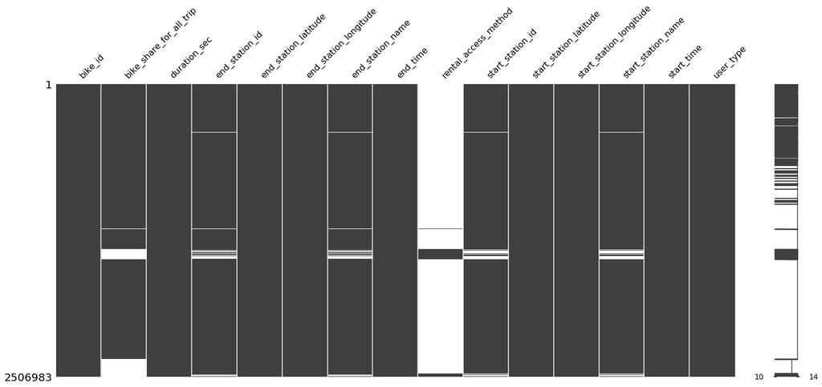

```python
# visualizing missing value
msno.matrix(bike_df);
```

```python
# missing value in each columns
bike_df.isnull().sum()
```

```
bike_id                          0
bike_share_for_all_trip     243259
duration_sec                     0
end_station_id               82902
end_station_latitude             0
end_station_longitude            0
end_station_name             82350
end_time                         0
rental_access_method       2386145
start_station_id             80734
start_station_latitude           0
start_station_longitude          0
start_station_name           80133
start_time                       0
user_type                        0
dtype: int64
```

```python
# values of 'user_type' column
bike_df['user_type'].value_counts()
```

```
Subscriber    2021166
Customer       485817
Name: user_type, dtype: int64
```

```python
# values of 'bike_share_for_all_trip' column
bike_df['bike_share_for_all_trip'].value_counts()
```

```
No     2086152
Yes     177572
Name: bike_share_for_all_trip, dtype: int64
```

```python
bike_df['bike_share_for_all_trip'].describe()
```

```
count     2263724
unique          2
top            No
freq      2086152
Name: bike_share_for_all_trip, dtype: object
```

```python
# values of 'rental_access_method' column
bike_df['rental_access_method'].value_counts()
```

```
app        108010
clipper     12828
Name: rental_access_method, dtype: int64
```

```python
# values of 'start_station_name' column
bike_df['start_station_name'].value_counts()
```

```
Market St at 10th St                                               45058
Berry St at 4th St                                                 42962
San Francisco Caltrain (Townsend St at 4th St)                     40302
San Francisco Ferry Building (Harry Bridges Plaza)                 39016
San Francisco Caltrain Station 2  (Townsend St at 4th St)          36576
Montgomery St BART Station (Market St at 2nd St)                   36081
Powell St BART Station (Market St at 4th St)                       34253
Steuart St at Market St                                            32448
Howard St at Beale St                                              31341
Powell St BART Station (Market St at 5th St)                       30581
The Embarcadero at Sansome St                                      28785
2nd St at Townsend St                                              24424
3rd St at Townsend St                                              23093
Embarcadero BART Station (Beale St at Market St)                   22094
4th St at Mission Bay Blvd S                                       21437
Townsend St at 7th St                                              21116
Beale St at Harrison St                                            20818
Civic Center/UN Plaza BART Station (Market St at McAllister St)    20551
4th St at 16th St                                                  20015
The Embarcadero at Steuart St                                      19219
Howard St at 8th St                                                18335
Bancroft Way at College Ave                                        17302
Post St at Kearny St                                               17158
Rhode Island St at 17th St                                         17100
8th St at Brannan St                                               16127
Bancroft Way at Telegraph Ave                                      16042
Townsend St at 5th St                                              15588
19th Street BART Station                                           15400
Downtown Berkeley BART                                             15316
Spear St at Folsom St                                              14835
                                                                   ...
Webster St at Clay St                                                 69
22nd St at William St                                                 65
Quesada Ave at 3rd St                                                 64
Carroll Ave at 3rd St                                                 60
Newbury Park Dr at King Rd                                            57
Willow St at Blewett Ave                                              50
Arguello Blvd at Edward St                                            50
Funston Ave at Clement St                                             46
23rd St at Taylor St                                                  45
9th Ave at Geary Blvd                                                 42
Devine St at San Pedro St                                             39
Jennings St at Revere Ave                                             38
Evans Ave at Mendell St                                               34
19th St at William St                                                 32
MTL-ECO5-01                                                           26
Columbia Ave at Bird Ave                                              23
St James St at 9th St                                                 22
Park Ave at Laurel Grove Ln                                           20
Egbert Ave at Jennings St                                             16
16th St Depot                                                         13
16th Depot Bike Fleet Station                                         11
Frida Kahlo Way at Cloud Cir                                          11
Woolsey St at Sacramento St1                                           7
Emeryville Depot                                                       6
Howard workshop - Station in a Box                                     5
Prototype Lab                                                          4
Mercado Way at Sierra Rd                                               3
San Jose Depot                                                         3
Philly Demo                                                            2
SF Test Station                                                        1
Name: start_station_name, Length: 446, dtype: int64
```

```python
bike_df['duration_sec'].describe()
```

```
count    2.506983e+06
mean     8.076483e+02
std      1.974714e+03
min      6.000000e+01
25%      3.590000e+02
50%      5.710000e+02
75%      8.870000e+02
max      9.121100e+05
Name: duration_sec, dtype: float64
```

```python
bike_df['duration_sec'].max()
```

```
912110
```

```python
# checking outliers in duration_sec
bike_df['duration_sec'].describe(percentiles=[.99])
```

```
count    2.506983e+06
mean     8.076483e+02
std      1.974714e+03
min      6.000000e+01
50%      5.710000e+02
99%      4.126000e+03
max      9.121100e+05
Name: duration_sec, dtype: float64
```

```python
# duplicate values in dataset
bike_df.duplicated().sum()
```

```
0
```

### Documenting Issuses

- Dropping un-neccessary columns like 'start_station_id', 'end_station_id', 'rental_access_method'.
- Removing null values from dataset.
- Changing data type of 'start_time' and 'end_time' to datetime.
- Changing data type of 'bike_id' to str.
- Changing data type of 'user_type' and 'bike_share_for_all_trip' to category.
- Separating date, hour, day, month from start_time and end_time columns.
- Converting ride duration from second to minute.
- Creating new column for bike ride distance.
- Sorting bike rides by start time.

## Cleaning Data

```python
# copying data
bay_df = bike_df.copy()
```

```python
# dropping un-neccessary columns
bay_df = bay_df.drop(['start_station_id', 'end_station_id', 'rental_access_method'], axis=1)
```

```python
# verifying columns are dropped
bay_df.info()
```

```
<class 'pandas.core.frame.DataFrame'>
RangeIndex: 2506983 entries, 0 to 2506982
Data columns (total 12 columns):
bike_id                    int64
bike_share_for_all_trip    object
duration_sec               int64
end_station_latitude       float64
end_station_longitude      float64
end_station_name           object
end_time                   object
start_station_latitude     float64
start_station_longitude    float64
start_station_name         object
start_time                 object
user_type                  object
dtypes: float64(4), int64(2), object(6)
memory usage: 229.5+ MB
```

```python
# removing null values from dataset
bay_df = bay_df.dropna()
```

```python
# verifying null values are removed
bay_df.isnull().sum()
```

```
bike_id                    0
bike_share_for_all_trip    0
duration_sec               0
end_station_latitude       0
end_station_longitude      0
end_station_name           0
end_time                   0
start_station_latitude     0
start_station_longitude    0
start_station_name         0
start_time                 0
user_type                  0
dtype: int64
```

```python
# changing datatype of 'start_time' and 'end_time' columns to datetime
bay_df['start_time'] = pd.to_datetime(bay_df['start_time'])
bay_df['end_time'] = pd.to_datetime(bay_df['end_time'])
```

```python
# changing datatype of 'bike_id' column to str
bay_df['bike_id'] = bay_df['bike_id'].astype('str')
```

```python
# chnaging datatype of 'user_type' and 'bike_share_for_all_trip' columns to category
bay_df['user_type'] = bay_df['user_type'].astype('category')
bay_df['bike_share_for_all_trip'] = bay_df['bike_share_for_all_trip'].astype('category')
```

```python
# verifying data type of columns is changed
bay_df.info()
```

```
<class 'pandas.core.frame.DataFrame'>
Int64Index: 2262979 entries, 0 to 2355470
Data columns (total 12 columns):
bike_id                    object
bike_share_for_all_trip    category
duration_sec               int64
end_station_latitude       float64
end_station_longitude      float64
end_station_name           object
end_time                   datetime64[ns]
start_station_latitude     float64
start_station_longitude    float64
start_station_name         object
start_time                 datetime64[ns]
user_type                  category
dtypes: category(2), datetime64[ns](2), float64(4), int64(1), object(3)
memory usage: 194.2+ MB
```

```python
# separating start_date, start_hour, start_day, start_month from start_time column
bay_df['start_date'] = bay_df.start_time.dt.strftime('%Y-%m-%d')
bay_df['start_hour'] = bay_df.start_time.dt.strftime('%H')
bay_df['start_day'] = bay_df.start_time.dt.strftime('%A')
bay_df['start_month'] = bay_df.start_time.dt.strftime('%B')
```

```python
# separating end_date, end_hour, end_day, end_month from end_time column
bay_df['end_date'] = bay_df.end_time.dt.strftime('%Y-%m-%d')
bay_df['end_hour'] = bay_df.end_time.dt.strftime('%H')
bay_df['end_day'] = bay_df.end_time.dt.strftime('%A')
bay_df['end_month'] = bay_df.end_time.dt.strftime('%B')
```

```python
# verifying date, hour, day and month are separated
bay_df.head()
```

|  | bike_id | bike_share_for_all_trip | duration_sec | end_station_latitude | end_station_longitude | end_station_name | end_time | start_station_latitude | start_station_longitude | start_station_name | start_time | user_type | start_date | start_hour | start_day | start_month | end_date | end_hour | end_day | end_month |
| --- | --- | --- | --- | --- | --- | --- | --- | --- | --- | --- | --- | --- | --- | --- | --- | --- | --- | --- | --- | --- |
| 0 | 4861 | No | 80825 | 37.808894 | -122.256460 | Grand Ave at Perkins St | 2019-02-01 16:24:49.864 | 37.775745 | -122.213037 | Foothill Blvd at 42nd Ave | 2019-01-31 17:57:44.613 | Subscriber | 2019-01-31 | 17 | Thursday | January | 2019-02-01 | 16 | Friday | February |
| 1 | 5506 | No | 65900 | 37.752428 | -122.420628 | Valencia St at 24th St | 2019-02-01 15:16:54.173 | 37.785881 | -122.408915 | Cyril Magnin St at Ellis St | 2019-01-31 20:58:33.886 | Subscriber | 2019-01-31 | 20 | Thursday | January | 2019-02-01 | 15 | Friday | February |
| 2 | 2717 | No | 62633 | 37.846784 | -122.291376 | 65th St at Hollis St | 2019-02-01 11:30:46.530 | 37.870139 | -122.268422 | Downtown Berkeley BART | 2019-01-31 18:06:52.924 | Customer | 2019-01-31 | 18 | Thursday | January | 2019-02-01 | 11 | Friday | February |
| 3 | 4557 | No | 44680 | 37.775946 | -122.437777 | Grove St at Divisadero | 2019-02-01 08:10:50.318 | 37.770083 | -122.429156 | Church St at Duboce Ave | 2019-01-31 19:46:09.719 | Customer | 2019-01-31 | 19 | Thursday | January | 2019-02-01 | 08 | Friday | February |
| 4 | 2100 | No | 60709 | 37.787168 | -122.388098 | The Embarcadero at Bryant St | 2019-02-01 07:10:51.065 | 37.794130 | -122.394430 | Steuart St at Market St | 2019-01-31 14:19:01.541 | Customer | 2019-01-31 | 14 | Thursday | January | 2019-02-01 | 07 | Friday | February |

```python
# creating new column contains ride duration in minute
bay_df['duration_min'] = bay_df['duration_sec']/60
```

```python
bay_df.head()
```

|  | bike_id | bike_share_for_all_trip | duration_sec | end_station_latitude | end_station_longitude | end_station_name | end_time | start_station_latitude | start_station_longitude | start_station_name | ... | user_type | start_date | start_hour | start_day | start_month | end_date | end_hour | end_day | end_month | duration_min |
| --- | --- | --- | --- | --- | --- | --- | --- | --- | --- | --- | --- | --- | --- | --- | --- | --- | --- | --- | --- | --- | --- |
| 0 | 4861 | No | 80825 | 37.808894 | -122.256460 | Grand Ave at Perkins St | 2019-02-01 16:24:49.864 | 37.775745 | -122.213037 | Foothill Blvd at 42nd Ave | ... | Subscriber | 2019-01-31 | 17 | Thursday | January | 2019-02-01 | 16 | Friday | February | 1347.083333 |
| 1 | 5506 | No | 65900 | 37.752428 | -122.420628 | Valencia St at 24th St | 2019-02-01 15:16:54.173 | 37.785881 | -122.408915 | Cyril Magnin St at Ellis St | ... | Subscriber | 2019-01-31 | 20 | Thursday | January | 2019-02-01 | 15 | Friday | February | 1098.333333 |
| 2 | 2717 | No | 62633 | 37.846784 | -122.291376 | 65th St at Hollis St | 2019-02-01 11:30:46.530 | 37.870139 | -122.268422 | Downtown Berkeley BART | ... | Customer | 2019-01-31 | 18 | Thursday | January | 2019-02-01 | 11 | Friday | February | 1043.883333 |
| 3 | 4557 | No | 44680 | 37.775946 | -122.437777 | Grove St at Divisadero | 2019-02-01 08:10:50.318 | 37.770083 | -122.429156 | Church St at Duboce Ave | ... | Customer | 2019-01-31 | 19 | Thursday | January | 2019-02-01 | 08 | Friday | February | 744.666667 |
| 4 | 2100 | No | 60709 | 37.787168 | -122.388098 | The Embarcadero at Bryant St | 2019-02-01 07:10:51.065 | 37.794130 | -122.394430 | Steuart St at Market St | ... | Customer | 2019-01-31 | 14 | Thursday | January | 2019-02-01 | 07 | Friday | February | 1011.816667 |

5 rows × 21 columns

```python
bay_df['duration_min'].describe()
```

```
count    2.262979e+06
mean     1.344884e+01
std      3.203676e+01
min      1.016667e+00
25%      5.966667e+00
50%      9.483333e+00
75%      1.473333e+01
max      1.436950e+03
Name: duration_min, dtype: float64
```

```python
# finding outliers in duration_min
bay_df['duration_min'].describe(percentiles=[.99])
```

```
count    2.262979e+06
mean     1.344884e+01
std      3.203676e+01
min      1.016667e+00
50%      9.483333e+00
99%      6.883333e+01
max      1.436950e+03
Name: duration_min, dtype: float64
```

```python
# function to find the distance of each ride
# I take reference from geeks of geeks

from math import radians, cos, sin, asin, sqrt

def dist_btwn_station(start_station,end_station):
    lat1, lon1 = start_station
    lat2, lon2 = end_station

    # radius of earth
    radius = 6371

    lat = radians(lat2 - lat1)
    lon = radians(lon2 - lon1)

    a = (sin(lat / 2)**2 + cos(radians(lat1)) * cos(radians(lat2)) * sin(lon / 2)**2)

    c = 2 * asin(sqrt(a))

    distance = radius * c

    return distance
```

```python
# applying function to each ride
bay_df['distance_km'] = bay_df.apply(lambda x: dist_btwn_station((x['start_station_latitude'], x['start_station_longitude']), (x['end_station_latitude'], x['end_station_longitude'])), axis=1)
```

```python
bay_df.head()
```

|  | bike_id | bike_share_for_all_trip | duration_sec | end_station_latitude | end_station_longitude | end_station_name | end_time | start_station_latitude | start_station_longitude | start_station_name | ... | start_date | start_hour | start_day | start_month | end_date | end_hour | end_day | end_month | duration_min | distance_km |
| --- | --- | --- | --- | --- | --- | --- | --- | --- | --- | --- | --- | --- | --- | --- | --- | --- | --- | --- | --- | --- | --- |
| 0 | 4861 | No | 80825 | 37.808894 | -122.256460 | Grand Ave at Perkins St | 2019-02-01 16:24:49.864 | 37.775745 | -122.213037 | Foothill Blvd at 42nd Ave | ... | 2019-01-31 | 17 | Thursday | January | 2019-02-01 | 16 | Friday | February | 1347.083333 | 5.305199 |
| 1 | 5506 | No | 65900 | 37.752428 | -122.420628 | Valencia St at 24th St | 2019-02-01 15:16:54.173 | 37.785881 | -122.408915 | Cyril Magnin St at Ellis St | ... | 2019-01-31 | 20 | Thursday | January | 2019-02-01 | 15 | Friday | February | 1098.333333 | 3.859628 |
| 2 | 2717 | No | 62633 | 37.846784 | -122.291376 | 65th St at Hollis St | 2019-02-01 11:30:46.530 | 37.870139 | -122.268422 | Downtown Berkeley BART | ... | 2019-01-31 | 18 | Thursday | January | 2019-02-01 | 11 | Friday | February | 1043.883333 | 3.287098 |
| 3 | 4557 | No | 44680 | 37.775946 | -122.437777 | Grove St at Divisadero | 2019-02-01 08:10:50.318 | 37.770083 | -122.429156 | Church St at Duboce Ave | ... | 2019-01-31 | 19 | Thursday | January | 2019-02-01 | 08 | Friday | February | 744.666667 | 0.999632 |
| 4 | 2100 | No | 60709 | 37.787168 | -122.388098 | The Embarcadero at Bryant St | 2019-02-01 07:10:51.065 | 37.794130 | -122.394430 | Steuart St at Market St | ... | 2019-01-31 | 14 | Thursday | January | 2019-02-01 | 07 | Friday | February | 1011.816667 | 0.953355 |

5 rows × 22 columns

```python
# finding outliers in distance_km
bay_df['distance_km'].describe(percentiles=[.99])
```

```
count    2.262979e+06
mean     1.971872e+00
std      5.953530e+01
min      0.000000e+00
50%      1.452567e+00
99%      5.030036e+00
max      1.279973e+04
Name: distance_km, dtype: float64
```

```python
bay_df.groupby('user_type')['distance_km'].describe()
```

| user_type | count | mean | std | min | 25% | 50% | 75% | max |
| --- | --- | --- | --- | --- | --- | --- | --- | --- |
| Customer | 402184.0 | 2.580442 | 98.828310 | 0.0 | 1.025458 | 1.619098 | 2.468815 | 12799.727782 |
| Subscriber | 1860795.0 | 1.840338 | 46.898159 | 0.0 | 0.910955 | 1.413548 | 2.176140 | 12798.346860 |

```python
# sorting all rides by start_time
bay_df = bay_df.sort_values(by=['start_time']).reset_index(drop=True)
```

```python
bay_df.head(10)
```

|  | bike_id | bike_share_for_all_trip | duration_sec | end_station_latitude | end_station_longitude | end_station_name | end_time | start_station_latitude | start_station_longitude | start_station_name | ... | start_date | start_hour | start_day | start_month | end_date | end_hour | end_day | end_month | duration_min | distance_km |
| --- | --- | --- | --- | --- | --- | --- | --- | --- | --- | --- | --- | --- | --- | --- | --- | --- | --- | --- | --- | --- | --- |
| 0 | 5117 | No | 226 | 37.867789 | -122.265896 | Fulton St at Bancroft Way | 2019-01-01 00:10:57.196 | 37.870139 | -122.268422 | Downtown Berkeley BART | ... | 2019-01-01 | 00 | Tuesday | January | 2019-01-01 | 00 | Tuesday | January | 3.766667 | 0.342664 |
| 1 | 1705 | No | 1767 | 37.765026 | -122.398773 | Jackson Playground | 2019-01-01 00:38:06.848 | 37.794130 | -122.394430 | Steuart St at Market St | ... | 2019-01-01 | 00 | Tuesday | January | 2019-01-01 | 00 | Tuesday | January | 29.450000 | 3.258663 |
| 2 | 4621 | Yes | 182 | 37.866043 | -122.258804 | Haste St at Telegraph Ave | 2019-01-01 00:12:58.748 | 37.862320 | -122.258801 | Telegraph Ave at Carleton St | ... | 2019-01-01 | 00 | Tuesday | January | 2019-01-01 | 00 | Tuesday | January | 3.033333 | 0.414001 |
| 3 | 4783 | Yes | 565 | 37.869360 | -122.254337 | Bancroft Way at College Ave | 2019-01-01 00:20:29.268 | 37.862320 | -122.258801 | Telegraph Ave at Carleton St | ... | 2019-01-01 | 00 | Tuesday | January | 2019-01-01 | 00 | Tuesday | January | 9.416667 | 0.875439 |
| 4 | 4892 | No | 710 | 37.816060 | -122.278244 | 24th St at Market St | 2019-01-01 00:26:38.421 | 37.797320 | -122.265320 | Lake Merritt BART Station | ... | 2019-01-01 | 00 | Tuesday | January | 2019-01-01 | 00 | Tuesday | January | 11.833333 | 2.373099 |
| 5 | 5112 | No | 606 | 37.771762 | -122.398438 | Berry St at King St | 2019-01-01 00:25:02.215 | 37.791464 | -122.391034 | The Embarcadero at Steuart St | ... | 2019-01-01 | 00 | Tuesday | January | 2019-01-01 | 00 | Tuesday | January | 10.100000 | 2.285329 |
| 6 | 4838 | No | 1917 | 37.781074 | -122.411738 | Civic Center/UN Plaza BART Station (Market St ... | 2019-01-01 00:47:09.221 | 37.789625 | -122.400811 | Montgomery St BART Station (Market St at 2nd St) | ... | 2019-01-01 | 00 | Tuesday | January | 2019-01-01 | 00 | Tuesday | January | 31.950000 | 1.351420 |
| 7 | 5423 | No | 1913 | 37.781074 | -122.411738 | Civic Center/UN Plaza BART Station (Market St ... | 2019-01-01 00:47:19.626 | 37.789625 | -122.400811 | Montgomery St BART Station (Market St at 2nd St) | ... | 2019-01-01 | 00 | Tuesday | January | 2019-01-01 | 00 | Tuesday | January | 31.883333 | 1.351420 |
| 8 | 5059 | No | 390 | 37.747998 | -122.420219 | Valencia St at Cesar Chavez St | 2019-01-01 00:23:07.253 | 37.763316 | -122.421904 | 17th St at Valencia St | ... | 2019-01-01 | 00 | Tuesday | January | 2019-01-01 | 00 | Tuesday | January | 6.500000 | 1.709682 |
| 9 | 5357 | No | 841 | 37.771058 | -122.402717 | Townsend St at 7th St | 2019-01-01 00:30:59.993 | 37.791464 | -122.391034 | The Embarcadero at Steuart St | ... | 2019-01-01 | 00 | Tuesday | January | 2019-01-01 | 00 | Tuesday | January | 14.016667 | 2.490534 |

10 rows × 22 columns

```python
# verifying every thing is correct
bay_df.info()
```

```
<class 'pandas.core.frame.DataFrame'>
RangeIndex: 2262979 entries, 0 to 2262978
Data columns (total 22 columns):
bike_id                    object
bike_share_for_all_trip    category
duration_sec               int64
end_station_latitude       float64
end_station_longitude      float64
end_station_name           object
end_time                   datetime64[ns]
start_station_latitude     float64
start_station_longitude    float64
start_station_name         object
start_time                 datetime64[ns]
user_type                  category
start_date                 object
start_hour                 object
start_day                  object
start_month                object
end_date                   object
end_hour                   object
end_day                    object
end_month                  object
duration_min               float64
distance_km                float64
dtypes: category(2), datetime64[ns](2), float64(6), int64(1), object(11)
memory usage: 349.6+ MB
```

## Storing Final Dataset

```python
bay_df.to_csv('bay_df_final.csv', index_label=False, encoding = 'utf-8')
```

## Structure of Dataset

The final dataset has 2262979 rows and 22 columns.

**Columns I dropped:**

| **Column Name** | **Column Description** | **Reason** |
| --- | --- | --- |
| **end_station_id** | Unique id of station at where trip ends. | Does not contribute in analysis. |
| **start_station_id** | Unique id of station at where trip starts. | Does not contribute in analysis. |
| **rental_access_method** | How bicycle ride is access either through app or clipper. | Contains too many null values about 2386145. |

**Columns I added:**

| **Column Name** | **Column Description** |
| --- | --- |
| **start_date** | Start date of ride. |
| **start_month** | Start month of ride. |
| **start_day** | Start day of ride. |
| **start_hour** | Start time of ride. |
| **end_date** | End date of ride. |
| **end_month** | End month of ride. |
| **end_day** | End day of ride. |
| **end_hour** | End time of ride. |
| **duration_min** | Ride duration in minute. |
| **distance_km** | Ride distance in kilometre. |

## Exploratory Data Analysis

```python
# reading dataset
bay_wheels = pd.read_csv('bay_df_final.csv')
```

```python
# viewing top rows
bay_wheels.head()
```

|  | bike_id | bike_share_for_all_trip | duration_sec | end_station_latitude | end_station_longitude | end_station_name | end_time | start_station_latitude | start_station_longitude | start_station_name | ... | start_date | start_hour | start_day | start_month | end_date | end_hour | end_day | end_month | duration_min | distance_km |
| --- | --- | --- | --- | --- | --- | --- | --- | --- | --- | --- | --- | --- | --- | --- | --- | --- | --- | --- | --- | --- | --- |
| 0 | 5117 | No | 226 | 37.867789 | -122.265896 | Fulton St at Bancroft Way | 2019-01-01 00:10:57.196 | 37.870139 | -122.268422 | Downtown Berkeley BART | ... | 2019-01-01 | 0 | Tuesday | January | 2019-01-01 | 0 | Tuesday | January | 3.766667 | 0.342664 |
| 1 | 1705 | No | 1767 | 37.765026 | -122.398773 | Jackson Playground | 2019-01-01 00:38:06.848 | 37.794130 | -122.394430 | Steuart St at Market St | ... | 2019-01-01 | 0 | Tuesday | January | 2019-01-01 | 0 | Tuesday | January | 29.450000 | 3.258663 |
| 2 | 4621 | Yes | 182 | 37.866043 | -122.258804 | Haste St at Telegraph Ave | 2019-01-01 00:12:58.748 | 37.862320 | -122.258801 | Telegraph Ave at Carleton St | ... | 2019-01-01 | 0 | Tuesday | January | 2019-01-01 | 0 | Tuesday | January | 3.033333 | 0.414001 |
| 3 | 4783 | Yes | 565 | 37.869360 | -122.254337 | Bancroft Way at College Ave | 2019-01-01 00:20:29.268 | 37.862320 | -122.258801 | Telegraph Ave at Carleton St | ... | 2019-01-01 | 0 | Tuesday | January | 2019-01-01 | 0 | Tuesday | January | 9.416667 | 0.875439 |
| 4 | 4892 | No | 710 | 37.816060 | -122.278244 | 24th St at Market St | 2019-01-01 00:26:38.421 | 37.797320 | -122.265320 | Lake Merritt BART Station | ... | 2019-01-01 | 0 | Tuesday | January | 2019-01-01 | 0 | Tuesday | January | 11.833333 | 2.373099 |

5 rows × 22 columns

```python
# viewing last rows
bay_wheels.tail()
```

|  | bike_id | bike_share_for_all_trip | duration_sec | end_station_latitude | end_station_longitude | end_station_name | end_time | start_station_latitude | start_station_longitude | start_station_name | ... | start_date | start_hour | start_day | start_month | end_date | end_hour | end_day | end_month | duration_min | distance_km |
| --- | --- | --- | --- | --- | --- | --- | --- | --- | --- | --- | --- | --- | --- | --- | --- | --- | --- | --- | --- | --- | --- |
| 2262974 | 3707 | No | 941 | 37.763281 | -122.407377 | Potrero Ave and Mariposa St | 2019-11-30 23:50:22.234 | 37.784872 | -122.400876 | Yerba Buena Center for the Arts (Howard St at ... | ... | 2019-11-30 | 23 | Saturday | November | 2019-11-30 | 23 | Saturday | November | 15.683333 | 2.467897 |
| 2262975 | 13069 | No | 205 | 37.783899 | -122.408445 | Powell St BART Station (Market St at 5th St) | 2019-11-30 23:43:36.490 | 37.780645 | -122.402866 | Folsom St at 5th St | ... | 2019-11-30 | 23 | Saturday | November | 2019-11-30 | 23 | Saturday | November | 3.416667 | 0.609369 |
| 2262976 | 284 | No | 348 | 37.318450 | -121.883172 | Willow St at Vine St | 2019-11-30 23:49:20.768 | 37.320866 | -121.876279 | 3rd St at Keyes St | ... | 2019-11-30 | 23 | Saturday | November | 2019-11-30 | 23 | Saturday | November | 5.800000 | 0.666207 |
| 2262977 | 12370 | No | 931 | 37.773717 | -122.411647 | Folsom St at 9th St | 2019-12-01 00:00:51.956 | 37.798014 | -122.405950 | Broadway at Kearny | ... | 2019-11-30 | 23 | Saturday | November | 2019-12-01 | 0 | Sunday | December | 15.516667 | 2.747625 |
| 2262978 | 12077 | No | 707 | 37.785881 | -122.408915 | Cyril Magnin St at Ellis St | 2019-12-01 00:06:34.378 | 37.776598 | -122.395282 | San Francisco Caltrain (Townsend St at 4th St) | ... | 2019-11-30 | 23 | Saturday | November | 2019-12-01 | 0 | Sunday | December | 11.783333 | 1.581418 |

5 rows × 22 columns

## Univariate Exploration

### Bike Rides by User Type

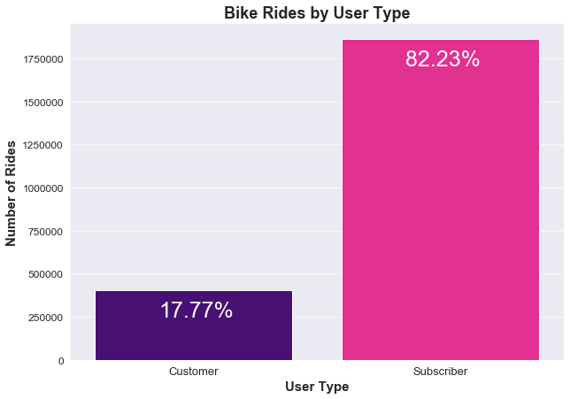

```python
# setting background style
sns.set_style('darkgrid')

# setting figure size
plt.figure(figsize=(10, 7))

ax = plt.subplot(111)

# plotting bar chart
ax = sns.countplot(data = bay_wheels, x='user_type', palette=['indigo','deeppink'], ax=ax)

# total number of rows
total = bay_wheels.shape[0]


for i in ax.patches:
    # get_x for left or right and get_height for up or down
    ax.text(i.get_x()+.26, i.get_height()-150000, \
            str(round((i.get_height()/total)*100, 2))+'%', fontsize=25, color='white')


plt.xlabel('User Type', fontsize=15, weight='bold')
plt.ylabel('Number of Rides', fontsize=15, weight='bold')
plt.xticks(fontsize=13)
plt.yticks(fontsize=12)
plt.title('Bike Rides by User Type', fontsize=18, weight='bold');
```

**Observation**

- About 82.23% of rides are done by subscriber of Bay Wheels bicycle sharing system and about 17.77% of rides are done by users who are not subscriber of bicycle sharing system.

### Bike Rides by Bike Share For All

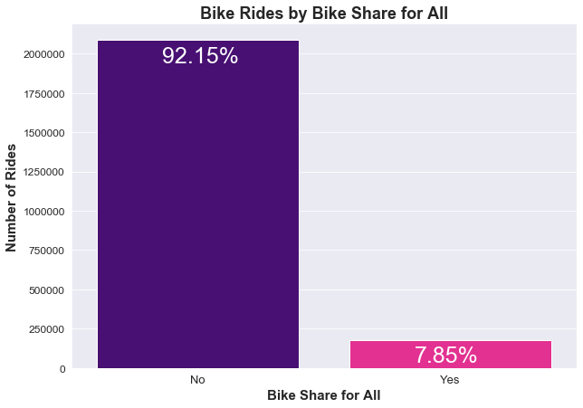

```python
plt.figure(figsize=(10, 7))

ax = plt.subplot(111)

ax = sns.countplot(data = bay_wheels, x='bike_share_for_all_trip', palette=['indigo','deeppink'], ax=ax)

total = bay_wheels.shape[0]

for i in ax.patches:
    # get_x for left or right and get_height for up or down
    ax.text(i.get_x()+.26, i.get_height()-140000, \
            str(round((i.get_height()/total)*100, 2))+'%', fontsize=25, color='white')


plt.xlabel('Bike Share for All', fontsize=15, weight='bold')
plt.ylabel('Number of Rides', fontsize=15, weight='bold')
plt.xticks(fontsize=13)
plt.yticks(fontsize=12)
plt.title('Bike Rides by Bike Share for All', fontsize=18, weight='bold');
```

**Observation**

- Only 7.85% of users are eligible for CalFresh, SFMTA Lifeline pass or PG&E CARE discount.
- Most of the users are not eligible for price reduction option.

### Bike Rides by Minutes

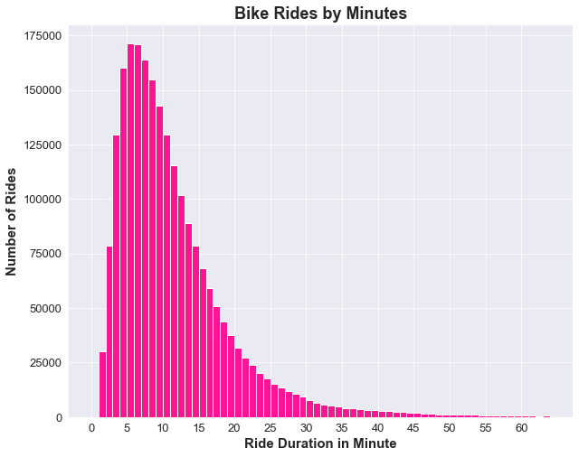

```python
plt.figure(figsize=(10,8))

# plotting histogram of ride duration
plt.hist(data=bay_wheels, x='duration_min',bins=np.arange(0, 65), color='deeppink')

plt.xlabel('Ride Duration in Minute', fontsize=15, weight='bold')
plt.ylabel('Number of Rides', fontsize=15, weight='bold')
plt.xticks(np.arange(0, 65, 5), fontsize=13)
plt.yticks(fontsize=13)
plt.title('Bike Rides by Minutes', fontsize=18, weight='bold');
```

**Observation**

- Most of the bicycle ride are between 5 to 15 minutes.
- There are only few rides which are avobe 25 minutes.

### Rides by Distance

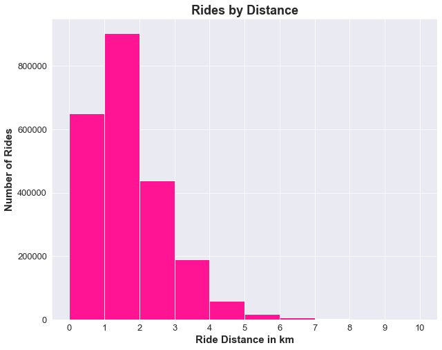

```python
plt.figure(figsize=(10,8))

plt.hist(data=bay_wheels, x='distance_km',bins=np.arange(0, 11), color='deeppink')

plt.xlabel('Ride Distance in km', fontsize=15, weight='bold')
plt.ylabel('Number of Rides', fontsize=15, weight='bold')
plt.xticks(np.arange(0, 11, 1), fontsize=13)
plt.yticks(fontsize=13)
plt.title('Rides by Distance', fontsize=18, weight='bold');
```

**Observation**

- Most of the rides are of 1 to 2 km.
- Very few rides are avobe 5 km.

### Rides by Days of Week

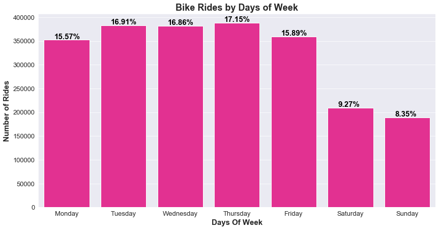

```python
plt.figure(figsize=(14,7))

ax = plt.subplot(111)

dow = ['Monday', 'Tuesday', 'Wednesday', 'Thursday', 'Friday', 'Saturday', 'Sunday']
dowcat = pd.api.types.CategoricalDtype(ordered=True, categories=dow)
bay_wheels['start_day'] = bay_wheels['start_day'].astype(dowcat)

ax = sns.countplot(data=bay_wheels, x='start_day', color='deeppink', ax=ax)

total = bay_wheels.shape[0]

for i in ax.patches:
    # get_x for left or right and get_height for up or down
    ax.text(i.get_x()+0.18, i.get_height()+ 2000, \
            str(round((i.get_height()/total)*100, 2))+'%', fontsize=15, weight='bold',
                color='black')

plt.xlabel('Days Of Week', fontsize=15, weight='bold')
plt.ylabel('Number of Rides', fontsize=15, weight='bold')
plt.xticks(fontsize=13)
plt.yticks(fontsize=13)
plt.title('Bike Rides by Days of Week', fontsize=18, weight='bold');
```

### Rides by Months

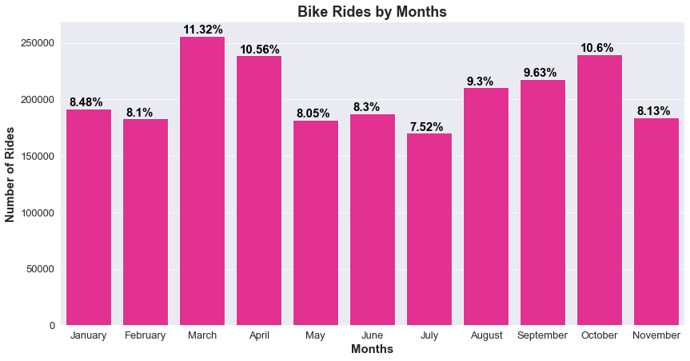

```python
plt.figure(figsize=(14,7))

ax = plt.subplot(111)

ax = sns.countplot(data=bay_wheels, x='start_month', color='deeppink', ax=ax)

total = bay_wheels.shape[0]

for i in ax.patches:
    # get_x for left or right and get_height for up or down
    ax.text(i.get_x()+0.06, i.get_height()+ 2000, \
            str(round((i.get_height()/total)*100, 2))+'%', fontsize=15, weight='bold',
                color='black')

plt.xlabel('Months', fontsize=15, weight='bold')
plt.ylabel('Number of Rides', fontsize=15, weight='bold')
plt.xticks(fontsize=13)
plt.yticks(fontsize=13)
plt.title('Bike Rides by Months', fontsize=18, weight='bold');
```

**Observation**

- Maximum rides are done in March, April and October.
- Minimum ride are done in July.

### Rides by Hours

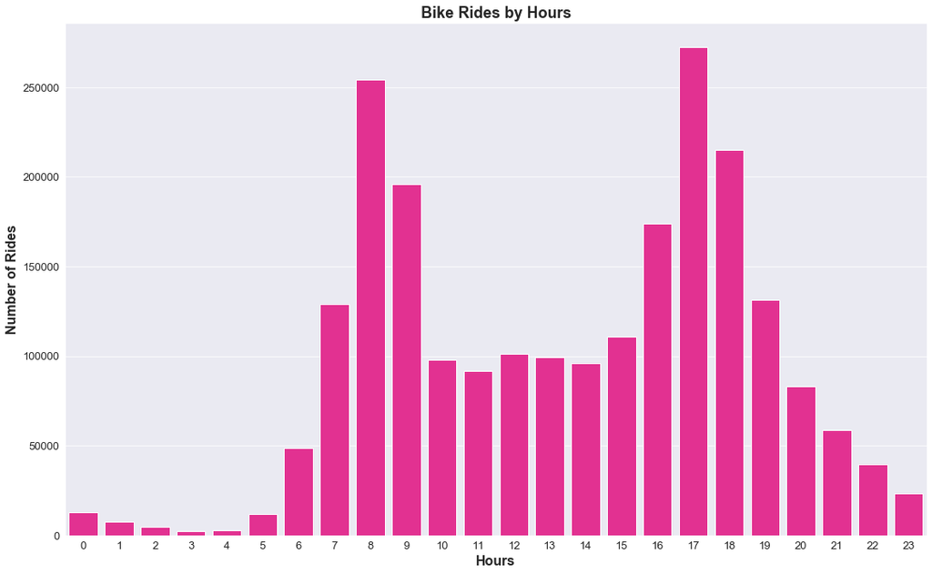

```python
plt.figure(figsize=(18,11))

ax = plt.subplot(111)

ax = sns.countplot(data=bay_wheels, x='start_hour', color='deeppink', ax=ax)

plt.ylabel('Number of Rides', fontsize=16, weight='bold')
plt.xlabel('Hours', fontsize=16, weight='bold')
plt.xticks(fontsize=13)
plt.yticks(fontsize=13)
plt.title('Bike Rides by Hours', fontsize=18, weight='bold');
```

**Observation**

- Rides were peak at 8 am and 5 pm.

### Top 30 Start Stations

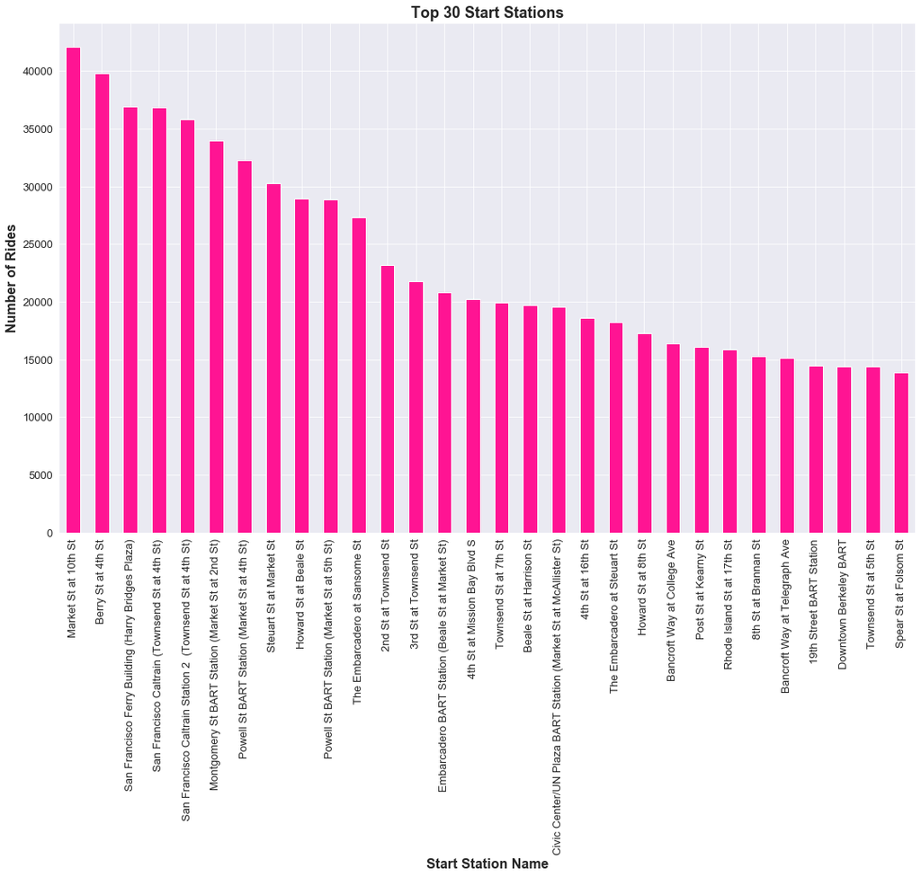

```python
plt.figure(figsize=(18,11))

bay_wheels['start_station_name'].value_counts().head(30).plot(kind='bar', color='deeppink')

plt.ylabel('Number of Rides', fontsize=16, weight='bold')
plt.xlabel('Start Station Name', fontsize=16, weight='bold')
plt.xticks(fontsize=13)
plt.yticks(fontsize=13)
plt.title('Top 30 Start Stations', fontsize=18, weight='bold');
```

### Top 30 End Station

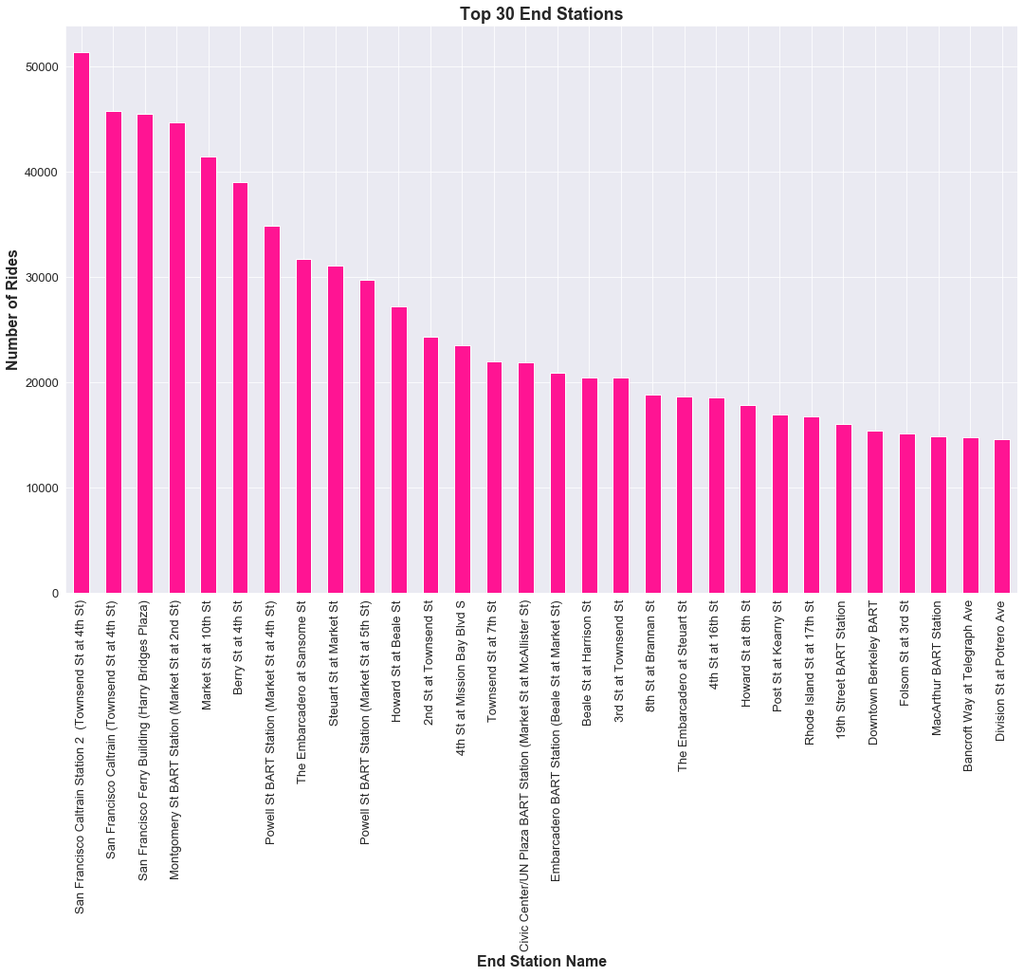

```python
plt.figure(figsize=(18,11))

bay_wheels['end_station_name'].value_counts().head(30).plot(kind='bar', color='deeppink')

plt.ylabel('Number of Rides', fontsize=16, weight='bold')
plt.xlabel('End Station Name', fontsize=16, weight='bold')
plt.xticks(fontsize=13)
plt.yticks(fontsize=13)
plt.title('Top 30 End Stations', fontsize=18, weight='bold');
```

## Bivariate Exploration

### Correlation Between Variables

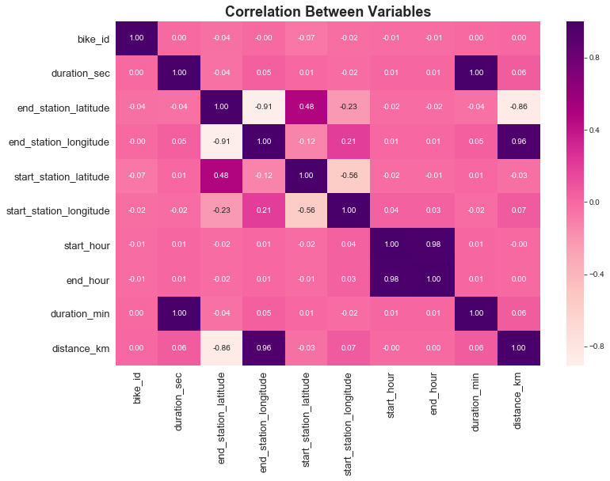

```python
plt.figure(figsize = [12,8])

sns.heatmap(bay_wheels.corr(), annot = True, fmt = '.2f', cmap = 'RdPu', center = 0)

plt.xticks(fontsize=13)
plt.yticks(fontsize=13)
plt.title('Correlation Between Variables', fontsize=18, weight='bold');
```

### Relation Between Variable

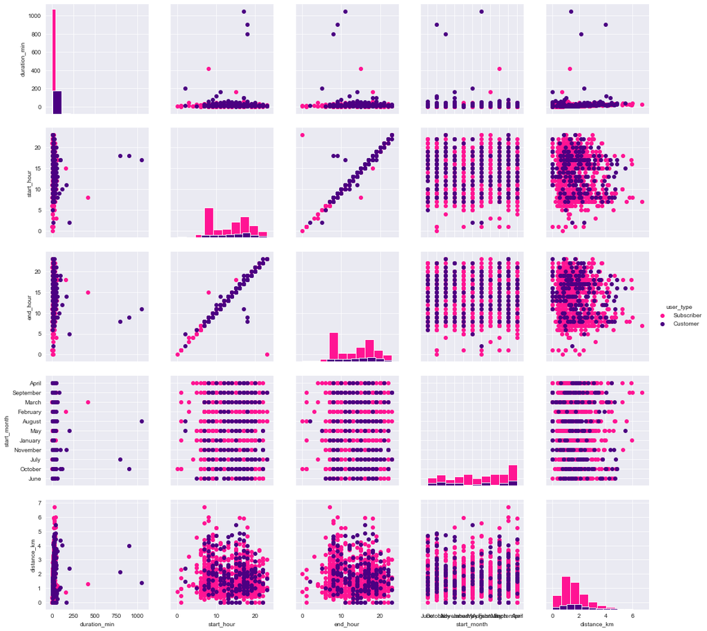

```python
samples = np.random.choice(bay_wheels.shape[0], 1000, replace=False)
bike_samples = bay_wheels.loc[samples, :]

g = sns.PairGrid(data=bike_samples, vars=['duration_min', 'start_hour','end_hour', 'start_month', 'distance_km'], palette=['deeppink','indigo'], hue='user_type')
g = g.map_diag(plt.hist)
g.map_offdiag(plt.scatter)
g.fig.set_size_inches(15,15)
g.add_legend();
```

**Observation**

- start_hour and end_hour are highly correlated.

### Heatmap of Ride Duration and Start Hour

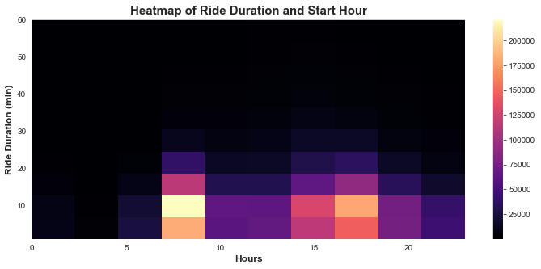

```python
data = bay_wheels.loc[bay_wheels['duration_min'] <= 60]

plt.figure(figsize=([12,5]))

plt.hist2d(data=data, x='start_hour', y='duration_min',  cmap='magma')

plt.colorbar()
plt.title('Heatmap of Ride Duration and Start Hour',fontsize=15,weight='bold')
plt.xlabel('Hours',fontsize=12,weight='bold')
plt.ylabel('Ride Duration (min)', fontsize=12,weight='bold');
```

**Observation**

- More people ride at 8 am and 5 pm for about 10 to 20 minutes.

### Heatmap of Ride Distance and Start Hour

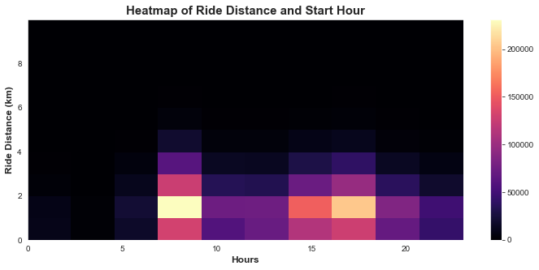

```python
data = bay_wheels.loc[bay_wheels['distance_km'] <= 10]

plt.figure(figsize=([12,5]))

plt.hist2d(data=data, x='start_hour', y='distance_km',  cmap='magma')

plt.colorbar()
plt.title('Heatmap of Ride Distance and Start Hour',fontsize=15, weight='bold')
plt.xlabel('Hours', fontsize=12, weight='bold')
plt.ylabel('Ride Distance (km)', fontsize=12, weight='bold');
```

**Observation**

- People ride for longer distance in morning than evening.

### Average Ride Duration and Distance by User Type

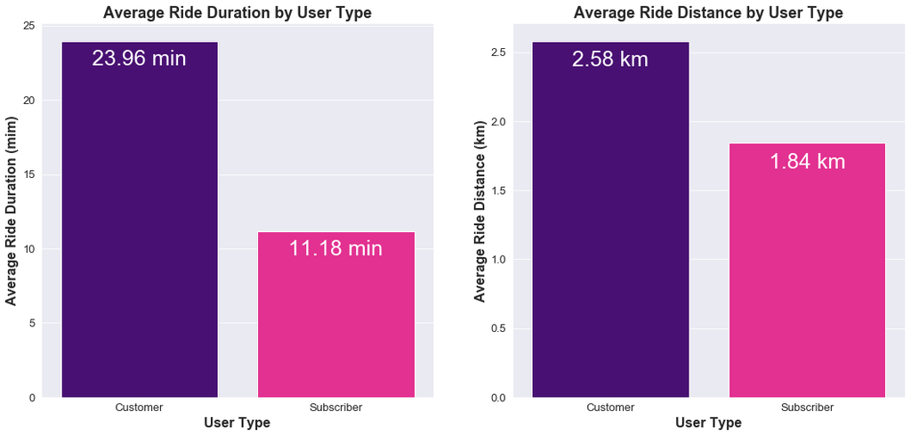

```python
plt.figure(figsize = [18,8])
avg_ride = bay_wheels.groupby('user_type').mean().reset_index()

plt.subplot(1,2,1)

ax = sns.barplot(x='user_type', y='duration_min', data=avg_ride, palette=['indigo','deeppink'])

for index, row in avg_ride.iterrows():
    ax.text(row.name,row.duration_min-1.6, str(round(row.duration_min,2))+' min', color='white', ha="center", fontsize=25)

plt.ylabel('Average Ride Duration (mim)', fontsize=16, weight='bold')
plt.xlabel('User Type', fontsize=16, weight='bold')
plt.xticks(fontsize=13)
plt.yticks(fontsize=13)
plt.title('Average Ride Duration by User Type', fontsize=18, weight='bold')


plt.subplot(1,2,2)

ax = sns.barplot(x='user_type', y='distance_km', data=avg_ride, palette=['indigo','deeppink'])

for index, row in avg_ride.iterrows():
    ax.text(row.name,row.distance_km-.18, str(round(row.distance_km,2))+' km', color='white', ha="center", fontsize=25)

plt.ylabel('Average Ride Distance (km)', fontsize=16, weight='bold')
plt.xlabel('User Type', fontsize=16, weight='bold')
plt.xticks(fontsize=13)
plt.yticks(fontsize=13)
plt.title('Average Ride Distance by User Type', fontsize=18, weight='bold');
```

**Observation**

- Average ride duration and distance for customer is more than subscriber.

### Average Ride Duration and Distance by Bike Share For All

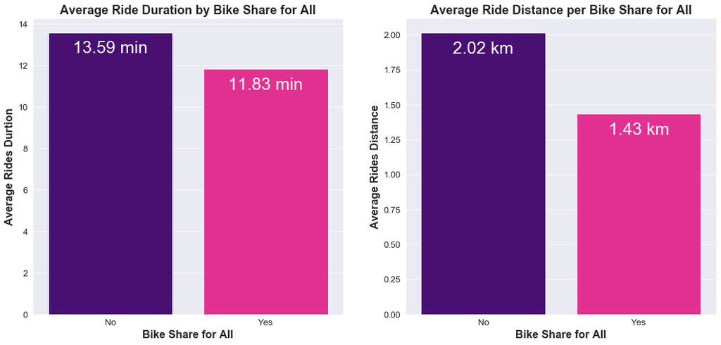

```python
plt.figure(figsize=(18,8))

avg_bike_share = bay_wheels.groupby('bike_share_for_all_trip').mean().reset_index()

plt.subplot(1,2,1)

ax = sns.barplot(x='bike_share_for_all_trip', y='duration_min', data=avg_bike_share, palette=['indigo','deeppink'])

for index, row in avg_bike_share.iterrows():
    ax.text(row.name,row.duration_min-1, str(round(row.duration_min,2))+' min', color='white', ha="center", fontsize=25)

plt.ylabel('Average Rides Durtion', fontsize=16, weight='bold')
plt.xlabel('Bike Share for All', fontsize=16, weight='bold')
plt.xticks(fontsize=13)
plt.yticks(fontsize=13)
plt.title('Average Ride Duration by Bike Share for All', fontsize=18, weight='bold')

plt.subplot(1,2,2)

ax = sns.barplot(x='bike_share_for_all_trip', y='distance_km', data=avg_bike_share, palette=['indigo','deeppink'])

for index, row in avg_bike_share.iterrows():
    ax.text(row.name,row.distance_km-.15, str(round(row.distance_km,2))+' km', color='white', ha="center", fontsize=25)

plt.ylabel('Average Rides Distance', fontsize=16, weight='bold')
plt.xlabel('Bike Share for All', fontsize=16, weight='bold')
plt.xticks(fontsize=13)
plt.yticks(fontsize=13)
plt.title('Average Ride Distance per Bike Share for All', fontsize=18, weight='bold');
```

**Observation**

- Average ride duration and distance is less for users who got discount than user who did not get discount.

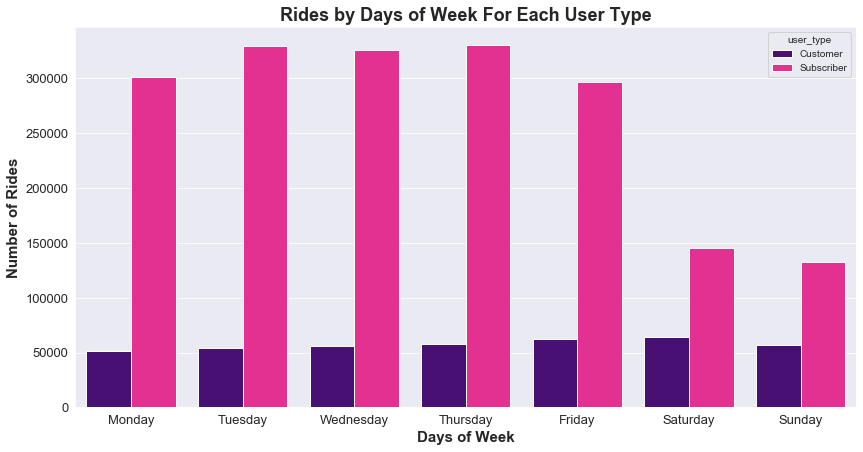

```python
plt.figure(figsize=(14,7))
ax = plt.subplot(111)

ax = sns.countplot(data=bay_wheels, x='start_day', palette=['indigo','deeppink'], hue='user_type', ax=ax)

plt.xlabel('Days of Week', fontsize=15, weight='bold')
plt.ylabel('Number of Rides', fontsize=15, weight='bold')
plt.xticks(fontsize=13)
plt.yticks(fontsize=13)
plt.title('Rides by Days of Week For Each User Type', fontsize=18, weight='bold');
```

**Observation**

- Customer rides less over days of week than subscriber.

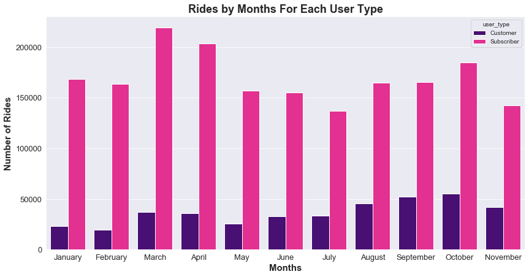

```python
plt.figure(figsize=(14,7))
ax = plt.subplot(111)

ax = sns.countplot(data=bay_wheels, x='start_month', palette=['indigo','deeppink'], hue='user_type', ax=ax)

plt.xlabel('Months', fontsize=15, weight='bold')
plt.ylabel('Number of Rides', fontsize=15, weight='bold')
plt.xticks(fontsize=13)
plt.yticks(fontsize=13)
plt.title('Rides by Months For Each User Type', fontsize=18, weight='bold');
```

**Observation**

- Subscriber take more ride than customer on each day of week or month.

### Average Ride Duration by Days of Week

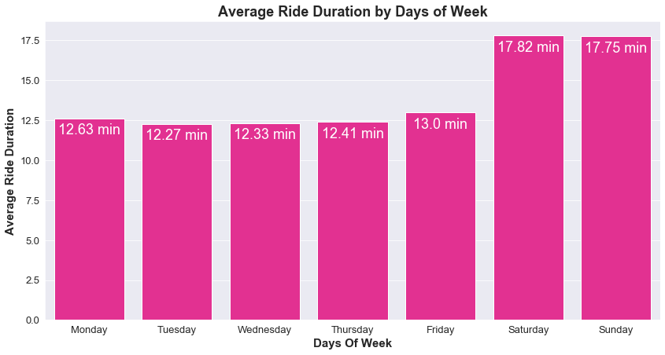

```python
plt.figure(figsize=(14,7))
ax = plt.subplot(111)

avg_bike_duration = bay_wheels.groupby('start_day').mean().reset_index()

ax = sns.barplot(data=avg_bike_duration, x='start_day', y='duration_min', color='deeppink', ax=ax)

for index, row in avg_bike_duration.iterrows():
    ax.text(row.name,row.duration_min-1, str(round(row.duration_min,2))+' min', color='white', ha="center", fontsize=18)

plt.xlabel('Days Of Week', fontsize=15, weight='bold')
plt.ylabel('Average Ride Duration', fontsize=15, weight='bold')
plt.xticks(fontsize=13)
plt.yticks(fontsize=13)
plt.title('Average Ride Duration by Days of Week', fontsize=18, weight='bold');
```

**Observation**

- Avearage ride duration of weekends is more than regular days. In other words peoples are riding for longer time on weekends.

### Average Ride Duration by Months

```python
months = ['January','February','March','April','May','June','July','August','September','October','November']

monthcat = pd.api.types.CategoricalDtype(ordered=True, categories=months)
bay_wheels['start_month'] = bay_wheels['start_month'].astype(monthcat)
```

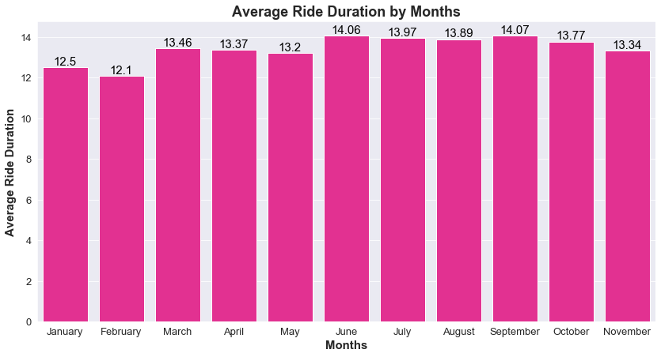

```python
plt.figure(figsize=(14,7))

avg_bike_month = bay_wheels.groupby('start_month').mean().reset_index()

ax = sns.barplot(data=avg_bike_month, x='start_month', y='duration_min', color='deeppink')

for index, row in avg_bike_month.iterrows():
    ax.text(row.name,row.duration_min+.1, str(round(row.duration_min,2)), color='black', ha="center", fontsize=15)

plt.xlabel('Months', fontsize=15, weight='bold')
plt.ylabel('Average Ride Duration', fontsize=15, weight='bold')
plt.xticks(fontsize=13)
plt.yticks(fontsize=13)
plt.title('Average Ride Duration by Months', fontsize=18, weight='bold');
```

**Observation**

- Average ride duration is maximum from June to September.

### Average Ride Distance by Days of Week

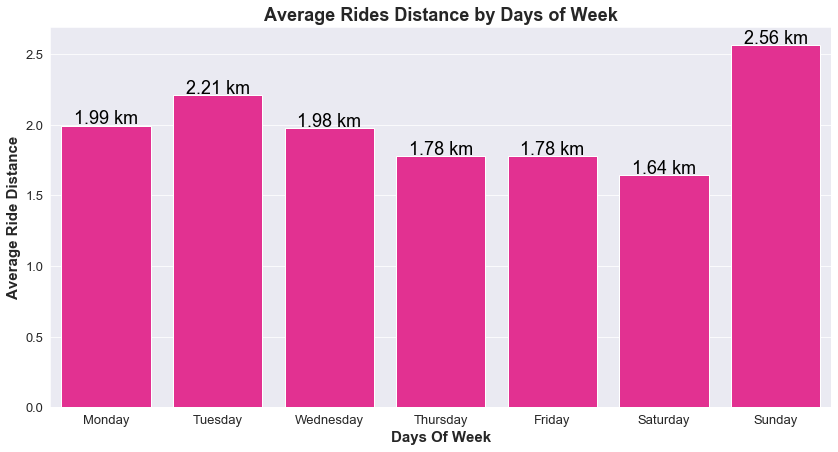

```python
plt.figure(figsize=(14,7))
ax = plt.subplot(111)

avg_bike_duration = bay_wheels.groupby('start_day').mean().reset_index()

ax = sns.barplot(data=avg_bike_duration, x='start_day', y='distance_km', color='deeppink', ax=ax)

for index, row in avg_bike_duration.iterrows():
    ax.text(row.name,row.distance_km+.01, str(round(row.distance_km,2))+' km', color='black', ha="center", fontsize=18)

plt.xlabel('Days Of Week', fontsize=15, weight='bold')
plt.ylabel('Average Ride Distance', fontsize=15, weight='bold')
plt.xticks(fontsize=13)
plt.yticks(fontsize=13)
plt.title('Average Rides Distance by Days of Week', fontsize=18, weight='bold');
```

**Observation**

- Average ride distance is maximum on Sunday.
- Average ride distance is minimum on Saturday.

### Average Ride Distance by Months

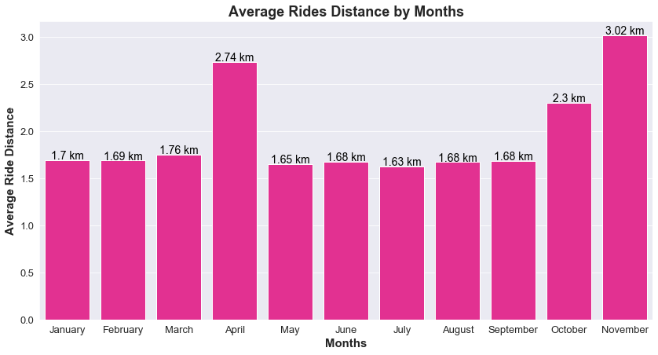

```python
plt.figure(figsize=(14,7))

avg_bike_month = bay_wheels.groupby('start_month').mean().reset_index()

ax = sns.barplot(data=avg_bike_month, x='start_month', y='distance_km', color='deeppink')

for index, row in avg_bike_month.iterrows():
    ax.text(row.name,row.distance_km+.01, str(round(row.distance_km,2))+' km', color='black', ha="center", fontsize=14)

plt.xlabel('Months', fontsize=15, weight='bold')
plt.ylabel('Average Ride Distance', fontsize=15, weight='bold')
plt.xticks(fontsize=13)
plt.yticks(fontsize=13)
plt.title('Average Rides Distance by Months', fontsize=18, weight='bold');
```

**Observation**

- Average ride distance is maximum on November.

### Ride Distribution by User Type and Bike Share For All

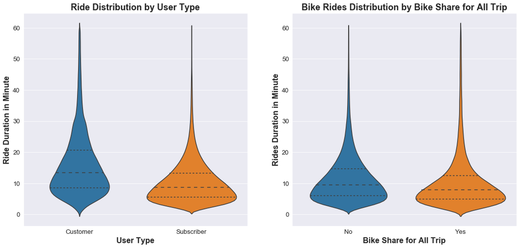

```python
plt.figure(figsize = [18,8])

data = bay_wheels.loc[bay_wheels['duration_min'] <= 60]

plt.subplot(1,2,1)

sns.violinplot(data =data, x = 'user_type', y='duration_min', inner='quartile')

plt.ylabel('Ride Duration in Minute', fontsize=16, weight='bold')
plt.xlabel('User Type', fontsize=16, weight='bold')
plt.xticks(fontsize=13)
plt.yticks(fontsize=13)
plt.title('Ride Distribution by User Type', fontsize=18, weight='bold')

plt.subplot(1,2,2)

sns.violinplot(data =data, x = 'bike_share_for_all_trip', y='duration_min', inner='quartile')

plt.ylabel('Rides Duration in Minute', fontsize=16, weight='bold')
plt.xlabel('Bike Share for All Trip', fontsize=16, weight='bold')
plt.xticks(fontsize=13)
plt.yticks(fontsize=13)
plt.title('Bike Rides Distribution by Bike Share for All Trip', fontsize=18, weight='bold');
```

### Ride Distribution by Days of Week

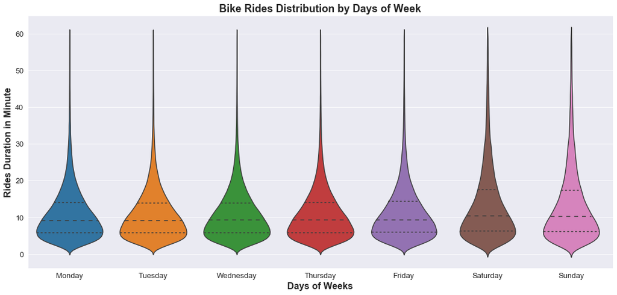

```python
# Bivariate plots of "duration_minute" vs. "user_type"
plt.figure(figsize = [18, 8])

data = bay_wheels.loc[bay_wheels['duration_min'] <= 60]

sns.violinplot(data =data, x = 'start_day', y='duration_min', inner='quartile')

plt.ylabel('Rides Duration in Minute', fontsize=16, weight='bold')
plt.xlabel('Days of Weeks', fontsize=16, weight='bold')
plt.xticks(fontsize=13)
plt.yticks(fontsize=13)
plt.title('Bike Rides Distribution by Days of Week', fontsize=18, weight='bold');
```

### Ride Distribution by Months

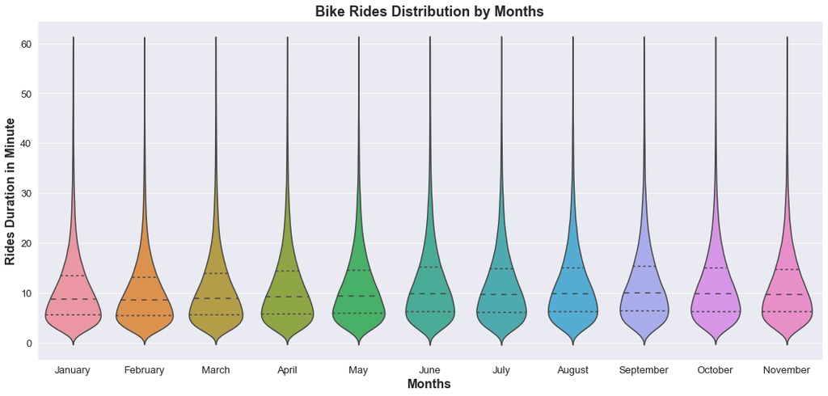

```python
# Bivariate plots of "duration_minute" vs. "user_type"
plt.figure(figsize = [18, 8])

data = bay_wheels.loc[bay_wheels['duration_min'] <= 60]

sns.violinplot(data =data, x='start_month' , y='duration_min', inner='quartile')

plt.ylabel('Rides Duration in Minute', fontsize=16, weight='bold')
plt.xlabel('Months', fontsize=16, weight='bold')
plt.xticks(fontsize=13)
plt.yticks(fontsize=13)
plt.title('Bike Rides Distribution by Months', fontsize=18, weight='bold');
```

### Ride Distance Distribution by Days of Week

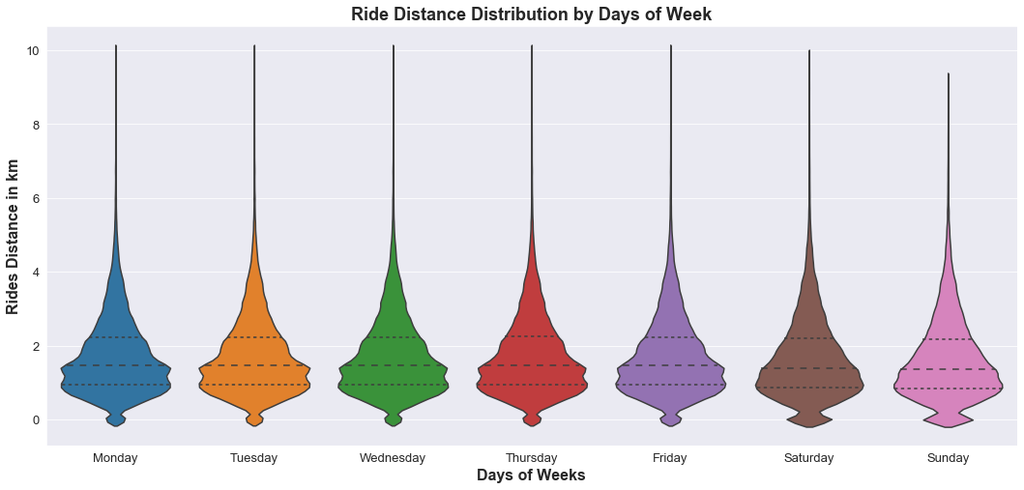

```python
# Bivariate plots of "duration_minute" vs. "user_type"
plt.figure(figsize = [18, 8])

data = bay_wheels.loc[bay_wheels['distance_km'] <= 10]

sns.violinplot(data =data, x = 'start_day', y='distance_km', inner='quartile')

plt.ylabel('Rides Distance in km', fontsize=16, weight='bold')
plt.xlabel('Days of Weeks', fontsize=16, weight='bold')
plt.xticks(fontsize=13)
plt.yticks(fontsize=13)
plt.title('Ride Distance Distribution by Days of Week', fontsize=18, weight='bold');
```

### Ride Distance Distribution by Month

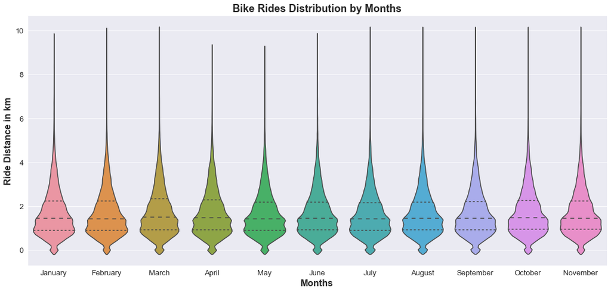

```python
# Bivariate plots of "duration_minute" vs. "user_type"
plt.figure(figsize = [18, 8])

data = bay_wheels.loc[bay_wheels['distance_km'] <= 10]

sns.violinplot(data =data, x='start_month' , y='distance_km', inner='quartile')

plt.ylabel('Ride Distance in km', fontsize=16, weight='bold')
plt.xlabel('Months', fontsize=16, weight='bold')
plt.xticks(fontsize=13)
plt.yticks(fontsize=13)
plt.title('Bike Rides Distribution by Months', fontsize=18, weight='bold');
```

## Multivariate Exploration

### Heatmap of Ride Duration and Start Hour For Each User Type

```python
bay_wheels_sub = bay_wheels.query('user_type == "Subscriber"')
data_sub = bay_wheels_sub.loc[bay_wheels_sub['duration_min'] <= 60]

bay_wheels_cus = bay_wheels.query('user_type == "Customer"')
data_cus = bay_wheels_cus.loc[bay_wheels_cus['duration_min'] <= 60]
```

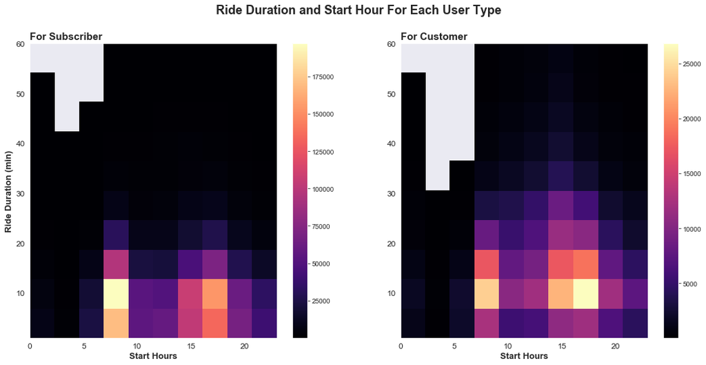

```python
plt.figure(figsize = [18, 8])

plt.subplot(1, 2, 1)
plt.hist2d(data=data_sub, x='start_hour', y='duration_min', cmap='magma', cmin=50)
plt.colorbar()
plt.xticks(fontsize=12)
plt.yticks(fontsize=12)
plt.xlabel('Start Hours',fontsize=13, weight='bold')
plt.ylabel('Ride Duration (min)',fontsize=13, weight='bold')
plt.title('For Subscriber', loc='left', fontsize=15, weight='bold')

plt.subplot(1, 2, 2)
plt.hist2d(data=data_cus, x='start_hour', y='duration_min', cmap='magma', cmin=50)
plt.colorbar()
plt.xticks(fontsize=12)
plt.yticks(fontsize=12)
plt.xlabel('Start Hours',fontsize=13, weight='bold')
plt.title('For Customer', loc='left', fontsize=15, weight='bold')

plt.suptitle('Ride Duration and Start Hour For Each User Type',fontsize=18,weight='bold');
```

**Observation**

- Subscriber ride more in the morning around 8 am and ride less in evening.
- Customer ride more in evening and less in morning.

### Heatmap of Ride Distance and Start Hour For Each User Type

```python
bay_wheels_sub = bay_wheels.query('user_type == "Subscriber"')
data_sub = bay_wheels_sub.loc[bay_wheels_sub['distance_km'] <= 10]

bay_wheels_cus = bay_wheels.query('user_type == "Customer"')
data_cus = bay_wheels_cus.loc[bay_wheels_cus['distance_km'] <= 10]
```

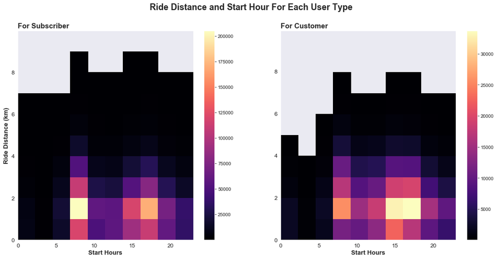

```python
plt.figure(figsize = [18, 8])

plt.subplot(1, 2, 1)
plt.hist2d(data=data_sub, x='start_hour', y='distance_km', cmap='magma', cmin=50)
plt.colorbar()
plt.xticks(fontsize=12)
plt.yticks(fontsize=12)
plt.xlabel('Start Hours',fontsize=13, weight='bold')
plt.ylabel('Ride Distance (km)',fontsize=13, weight='bold')
plt.title('For Subscriber', loc='left', fontsize=15, weight='bold')

plt.subplot(1, 2, 2)
plt.hist2d(data=data_cus, x='start_hour', y='distance_km', cmap='magma', cmin=50)
plt.colorbar()
plt.xticks(fontsize=12)
plt.yticks(fontsize=12)
plt.xlabel('Start Hours',fontsize=13, weight='bold')
plt.title('For Customer', loc='left', fontsize=15, weight='bold')

plt.suptitle('Ride Distance and Start Hour For Each User Type', fontsize=18, weight='bold');
```

**Observation**

- In morning subscriber ride for longer distance than customer.
- In evening customer ride for longer distance than subscriber.

### Hourly and Weekly Rides for Each User Type

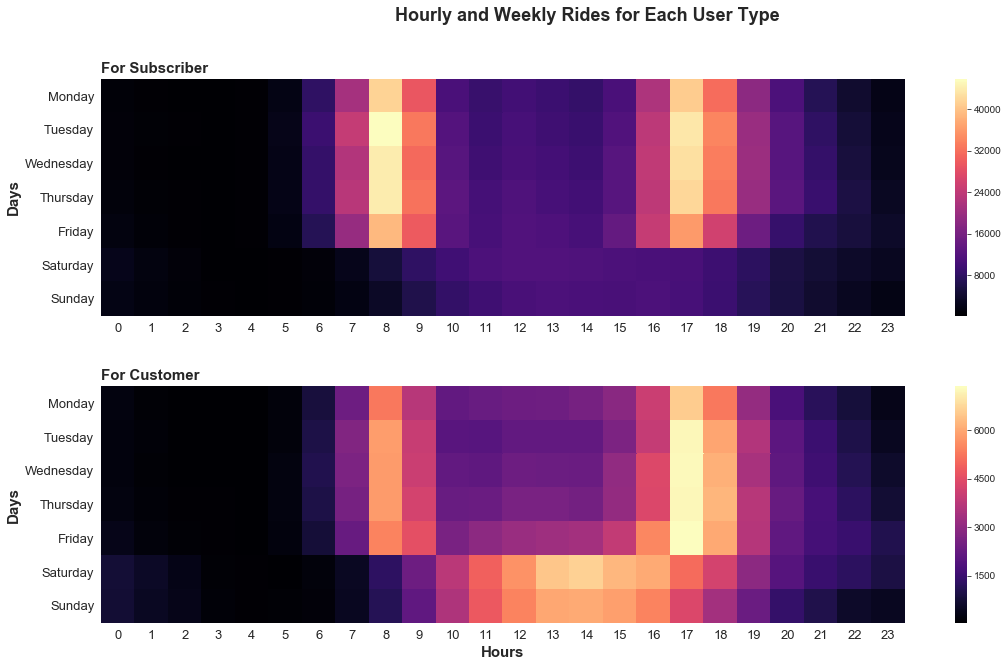

```python
plt.figure(figsize = [18, 10])

plt.subplot(2, 1, 1)

sub_count = bay_wheels_sub.groupby(['start_day', 'start_hour']).size()
sub_count = sub_count.reset_index(name='count')
sub_count = sub_count.pivot(index='start_day', columns='start_hour', values='count')
sns.heatmap(sub_count, cmap='magma')
plt.title('For Subscriber', loc='left', fontsize=15, weight='bold')
plt.xticks(fontsize=13)
plt.yticks(fontsize=13)
plt.xlabel('', fontsize=15, weight='bold')
plt.ylabel('Days', fontsize=15, weight='bold')

plt.subplot(2, 1, 2)

cus_count = bay_wheels_cus.groupby(['start_day', 'start_hour']).size()
cus_count = cus_count.reset_index(name='count')
cus_count = cus_count.pivot(index='start_day', columns='start_hour', values='count')
sns.heatmap(cus_count, cmap='magma')
plt.title('For Customer', loc='left', fontsize=15, weight='bold')
plt.xticks(fontsize=13)
plt.yticks(fontsize=13)
plt.xlabel('Hours', fontsize=15, weight='bold')
plt.ylabel('Days', fontsize=15, weight='bold')

plt.subplots_adjust(hspace = 0.3)
plt.suptitle('Hourly and Weekly Rides for Each User Type', fontsize=18, weight='bold');
```

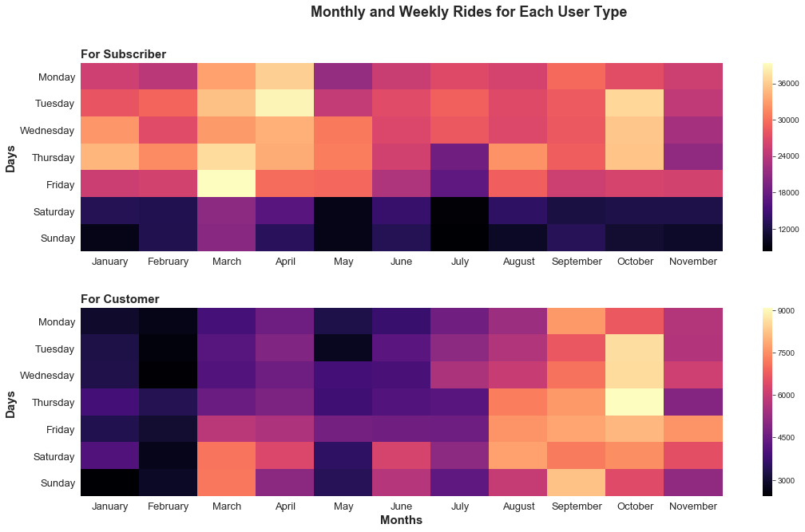

```python
plt.figure(figsize = [18, 10])

plt.subplot(2, 1, 1)

sub_count = bay_wheels_sub.groupby(['start_day', 'start_month']).size()
sub_count = sub_count.reset_index(name='count')
sub_count = sub_count.pivot(index='start_day', columns='start_month', values='count')
sns.heatmap(sub_count, cmap='magma')
plt.title('For Subscriber', loc='left', fontsize=15, weight='bold')
plt.xticks(fontsize=13)
plt.yticks(fontsize=13)
plt.xlabel('', fontsize=15, weight='bold')
plt.ylabel('Days', fontsize=15, weight='bold')

plt.subplot(2, 1, 2)

cus_count = bay_wheels_cus.groupby(['start_day', 'start_month']).size()
cus_count = cus_count.reset_index(name='count')
cus_count = cus_count.pivot(index='start_day', columns='start_month', values='count')
sns.heatmap(cus_count, cmap='magma')
plt.title('For Customer', loc='left', fontsize=15, weight='bold')
plt.xticks(fontsize=13)
plt.yticks(fontsize=13)
plt.xlabel('Months', fontsize=15, weight='bold')
plt.ylabel('Days', fontsize=15, weight='bold')

plt.subplots_adjust(hspace = 0.3)
plt.suptitle('Monthly and Weekly Rides for Each User Type', fontsize=18, weight='bold');
```

### Scatter Plot of Start Hour and Duration For Each User Type

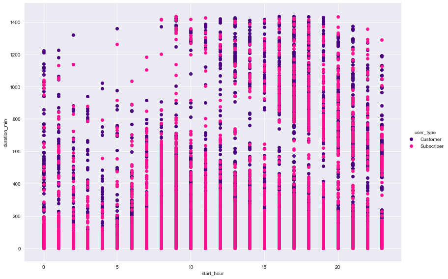

```python
g = sns.FacetGrid(data=bay_wheels, hue='user_type', palette=['indigo','deeppink'], height=8)
g.map(plt.scatter, 'start_hour', 'duration_min')
g.fig.set_size_inches(12,8)
g.add_legend();
```